# Database interoperability, uncertainty quantification and reproducible workflows in the paleogeosciences

Nicholas McKay

Northern Arizona University  
nick@nau.edu

Julien Emile-Geay

University of Southern California  
julieneg@usc.edu

Deborah Khider

University of Southern California  
Khider@usc.edu

2022/04/22

# 1 Abstract

The paleogeosciences are becoming more and more interdisciplinary, and studies increasingly rely on large collections of data derived from multiple data repositories. Integrating diverse datasets from multiple sources into complex workflows increases the challenge of creating reproducible and open science, as data formats and tools are often noninteroperable, requiring manual manipulation of data into standardized formats, resulting in a disconnect in data provenance and confounding reproducibility. Here we present a notebook that demonstrates how the Linked PaleoData (LiPD) framework is used as an interchange format to allow data from multiple data sources to be integrated in a complex workflow using emerging packages in R for geochronological uncertainty quantification and abrupt change detection. Specifically, in this notebook, we use the neotoma2 and lipdR packages to access paleoecological data from the Neotoma Database, and paleoclimate data from compilations hosted on Lipdverse. Age uncertainties for datasets from both sources are then quantified using the geoChronR package, and those data, and their associated age uncertainties, are then investigated for abrupt changes using the actR package, with accompanying visualizations. The result is an integrated, reproducible workflow in R that demonstrates how this complex series of multisource data integration, analysis and visualization can be integrated into an efficient, open scientific narrative.

# 2 Purpose

# 3 Technical contributions

This notebook highlights recent advances in multiple R packages

# 4 Methodology

# 5 Results

This notebook demonstrates how the Linked PaleoData (LiPD) framework can be used as an interchange format to allow data from multiple data sources to be integrated in a complex workflow using emerging packages in R for geochronological uncertainty quantification and abrupt change detection. Efficient workflows that support data from multiple sources are an important component of reproducible science.

# 6 Funding

This project is funded as part of the Belmont Forum’s Science-driven e-Infrastructure Innovation (SEI) initiative. In the US, this is NSF award ICER-1929460.

# 7 Citation

# 8 Acknowledgements

Thank you to Socorro Dominguez Vidana and Simon Goring for their work on the `neotoma2` and to the scientists who generated and shared the Bambili pollen data and the MD03-2707 paleotemperature data.

# 9 Setup

You will need to download the Rmd, HTML and bibtex file from the earthcube repository, store it in a single directory and then set up a project (see [this link](https://swcarpentry.github.io/r-novice-gapminder/02-project-intro/) for further discussion of this.) Then you can either knit the markdown file, or run the cells interactively.

## 9.2 Data processing and analysis

The paleogeosciences are becoming more and more interdisciplinary, and studies increasingly rely on large collections of data derived from multiple data repositories. Integrating diverse datasets from multiple sources into complex workflows increases the challenge of creating reproducible and open science, as data formats and tools are often noninteroperable, requiring manual manipulation of data into standardized formats, resulting in a disconnect in data provenance and confounding reproducibility. Here, we illustrate a use case where a scientist wants to conduct age-uncertain abrupt-change analysis on two datasets from Africa - a pollen record from Lake Bambili, and a temperature reconstruction from the Gulf of Guinea.

### 9.2.1 Lake Bambili

Lake Bambili is a high-elevation (2273 masl) crater lake in Cameroon (05° 56′ 11.9 N, 10°14′ 31.6 E) in the highlands of equatorial West Africa. Recently, Lezine et al. (2019) published a study using pollen data to show changes in forest composition over the past 90,000 years. In this notebook, we’ll take a look at abrupt shifts in these pollen assemblages, and compare them changes in a nearby climate record from the Gulf of Guinea.

Thankfully, Lezine et al. (2019) archived their pollen assemblage data at Neotoma, and we’ll use the `neotoma2` package to access the data, in this case, searching by sitename.

```r
L <- neotoma2::get_sites(sitename = "Bambili 2") %>% #Find the site of interest
  neotoma2::get_downloads() %>% #download the data for this site
  lipdR::neotoma2lipd() #convert the site object into a LiPD object
```

Now that we’ve downloaded the data and converted it to a LiPD object, it’s ready to be used in LinkedEarth’s ecosystem of tools built around the LiPD standard (e.g., geoChronR, actR, pyleoclim)

First, let’s quickly create a map using the `mapLipd()` function in geoChronR to visualize Lake Bambili’s location in equatorial west Africa.

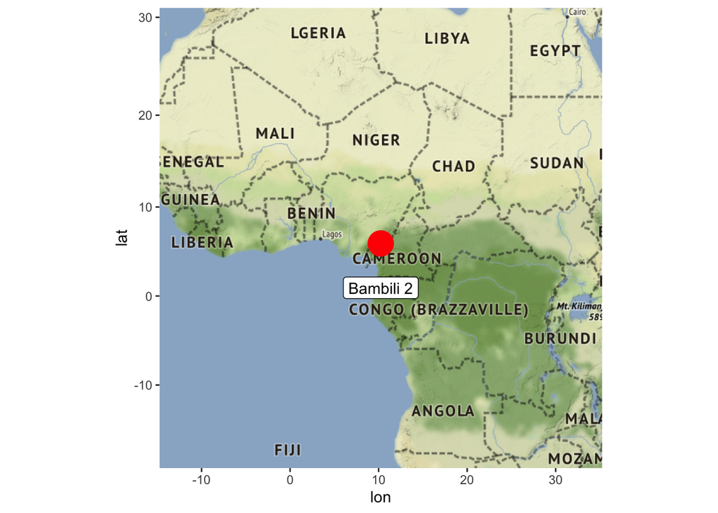

```r
mapLipd(L,map.type = "stamen",extend.range = 5)
```

### 9.2.2 Age modelling

In this notebook, we want to take a look at some of the abrupt changes in ecosystems recorded by pollen assemblages in this lake, while propagating age uncertainties. Neotoma does not store age ensembles, so we will need to generate a new age model. Here we’ll use Bacon (Blaauw and Christen 2011), one of the methods built into geoChronR, to create an age model and import the ensembles into the LiPD structure. Here, we’ve specified alll of the parameters so it will run without input, but it’s often convenient to call `runBacon()` with fewer inputs and run it interactively.

```r
L <- geoChronR::runBacon(L,
              lab.id.var = 'neotomaChronConrolId',
              age.14c.var = NULL,
              age.14c.uncertainty.var = NULL,
              age.var = 'age',
              age.uncertainty.var = 'ageUnc',
              depth.var = 'depth',
              reservoir.age.14c.var = NULL,
              reservoir.age.14c.uncertainty.var = NULL,
              rejected.ages.var = NULL,
              plot.pdf = FALSE,
              accept.suggestions = TRUE)
```

Now that the age model has finished running and the results are stored in the LiPD object, let’s plot the results.

```
## [1] "Found it! Moving on..."
## [1] "Found it! Moving on..."
## [1] "plotting your chron ensemble. This make take a few seconds..."
```

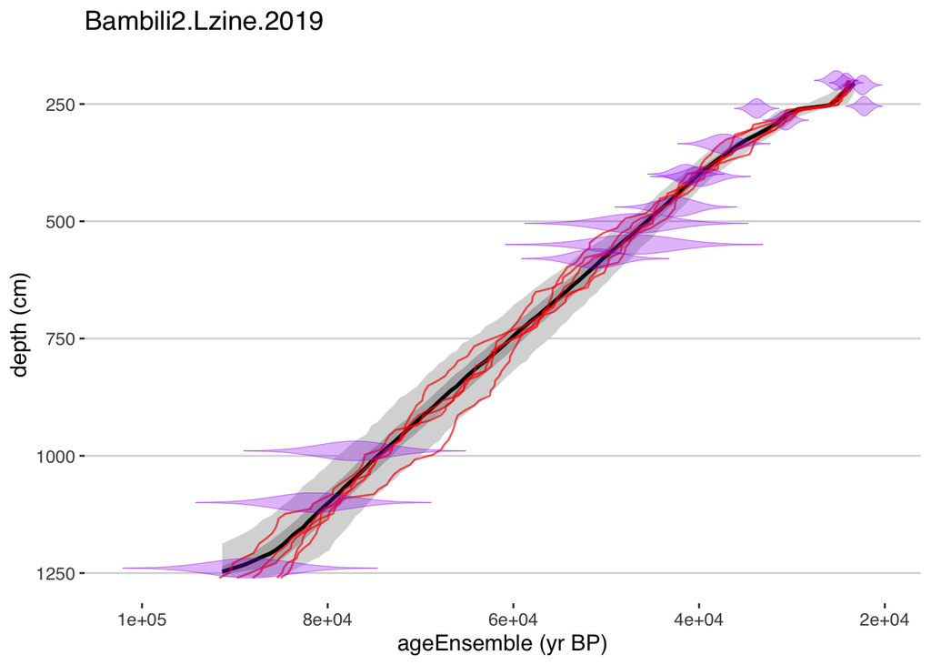

```r
plotChronEns(L)
```

Great, the uncertainties represented here are what we’d like to propagate through the abrupt change analysis. To do this, the first step is to “map” the age ensemble from the age model to the depths of the pollen data stored in the paleoData tables.

```r
L <- mapAgeEnsembleToPaleoData(L)
```

```
## [1] "Bambili2.Lzine.2019"
## [1] "Looking for age ensemble...."
## [1] "Found it! Moving on..."
## [1] "Found it! Moving on..."
## [1] "getting depth from the paleodata table..."
## [1] "Found it! Moving on..."
```

Now that that’s done, let’s select the paleoData age ensemble for future reference.

```r
ageEnsemble <- selectData(L,"ageEnsemble")
```

```
## [1] "Found it! Moving on..."
```

### 9.2.3 Paleoecological data analysis

Now let’s do some analysis on the paleoecological data. For this example, we will just perform a simple calculation. We’re interested in percent of pollen counts that are classified as trees or shrubs by their “ecological group.”

To do this, we will take advantage of lipdR’s integration with tidyverse tools in R. So our first step will be to convert the LiPD dataset into a specialized “tibble” object. It’s a regular tibble, where each row is a variable in the dataset, which includes all the metadata, and nested variables for time and paleodata values. We then use `dplyr` tools to calculate the total amount of tree and shrub pollen counts for each sample. Finally, we use the `magrittr` pipe for efficiency and clarity. See the comments in the code block for step by step explanations.

```r
TRSH <- as.lipdTsTibble(L) %>% #convert the LiPD object to a LiPD Timeseries Tibble object
  dplyr::filter(paleoData_ecologicalgroup == "TRSH") %>% #retain only the variables that are in the trees and shrubs ecological group
  lipdR::tabulateTs(time.var = "age") %>% #convert this filtered lipd-ts-tibble to a traditional paleoecological data table, with observations in the rows and age and pollen variables in the columns
  dplyr::rowwise() %>% #set up the analysis to row runwise
  dplyr::mutate(total = sum(c_across(-age),na.rm = TRUE)) #and use mutate to calculate a new column, the sum of all pollen counts.
```

Great, we now have a regular tibble that includes all our sample levels, and a new “total” column that we’ve calculated. This will be the numerator in our “percent trees and shrubs” calculation. Let’s repeat this process but with all of the non-aquatic pollen groups to ge the denominator.

```r
total <- as.lipdTsTibble(L) %>%
  dplyr::filter(paleoData_ecologicalgroup %in% c("TRSH","UPHE","VACR","SUCC","MANG")) %>%
  tabulateTs(time.var = "age") %>%
  rowwise() %>%
  mutate(total = sum(c_across(-age),na.rm = TRUE))
```

Now we can calculate the percentage of tree and shrub pollen relative to total non-aquatic pollen.

```r
treeShrubPercent <- TRSH$total/total$total * 100
```

Now let’s plot that percentage, along with the age ensemble, to visualize these data and their corresponding age uncertainties.

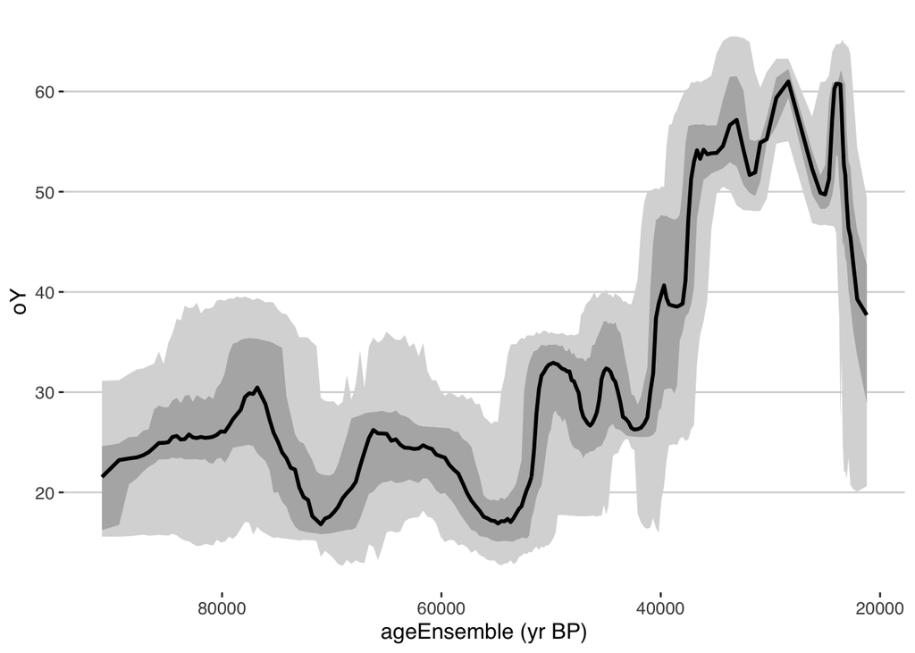

```r
geoChronR::plotTimeseriesEnsRibbons(X = ageEnsemble, Y =  treeShrubPercent)
```

Interesting, it does look like there are some rapid changes in this dataset that are worth further exploration.

### 9.2.4 Abrupt changes equatorial west African forest composition

We’ve now used the data we accessed from neotoma to generate an age ensemble, and a derived paleoecological indicator, and we’re ready to analyze these data to test whether or not the apparent abrupt shifts stand out given age uncertainties and a robust null hypothesis. To do this, we’ll use the “abrupt change toolkit in R (actR)” package to test for shifts in the mean of these data. actR can accept lipd-ts-tibble data directly, or data, ensembles and metadata separately. In this case, since we generated the paleoecological indicator outside of LiPD, we’ll use the latter strategy and specify the data explicitly.

```r
treeShrubMeanShift <- actR::detectShift(time = ageEnsemble$values, #matrix of age ensemble data
                  time.variable.name = "age", #variable name
                  time.units = "BP", # and units
                  vals = treeShrubPercent, #our paleoecological indicator (This could also be an ensemble if desired)
                  vals.variable.name = "Tree/Shrub", #variable name
                  vals.units = "%", # and units
                  summary.bin.step = 500, #over what timestep should we examine the results?
                  time.range = c(20000,90000)) #over what time range should we conduct the analysis.
```

```
## Testing null hypothesis with 100 simulations, each with 100 ensemble members.
## This will probably take about 2 minutes
```

Because this methodology tests for abrupt shifts across the age ensemble and repeats the entire process with a null model to evaluate the robust null hypothesis level, it can take awhile to run.

Let’s take a look at the results. The `print()` or `summarize()` methods will give some key details.

```r
print(treeShrubMeanShift)
```

```
## Tree/Shrub: Shift in Mean results
## Searched for Shift in Mean with a minimum segment length of 1 years, summarizing the results over windows of 500 years.
##
## Overall result: Detected 5 Shift in Mean event(s) that were significant at the alpha < 0.05 level
## # A tibble: 5 × 3
##   time_start time_end empirical_pvalue
##        <dbl>    <dbl>            <dbl>
## 1     37379.   37879.           0.0100
## 2     40879.   41379.           0.0200
## 3     39879.   40379.           0.0200
## 4     39379.   39879.           0.0200
## 5     38879.   39379.           0.0400
## Time uncertainty considered? TRUE Time ensemble supplied (n = 1000)
## Paleo uncertainty considered? TRUE Values ensemble generated in `propagateUncertainties()`)
## Error propagation ensemble members = 100
## Null hypothesis testing ensemble members = 100
## Members simulated using isospectral method
##
## Parameter choices:
## cpt.fun = changepoint::cpt.mean
## minimum.segment.length = 1
## method = AMOC
## penalty = MBIC
## ncpts.max = 1
```

These summaries are helpful, but ultimately, a visualization is often much more useful. Let’s plot the results:

```
## geom_path: Each group consists of only one observation. Do you need to adjust
## the group aesthetic?
```

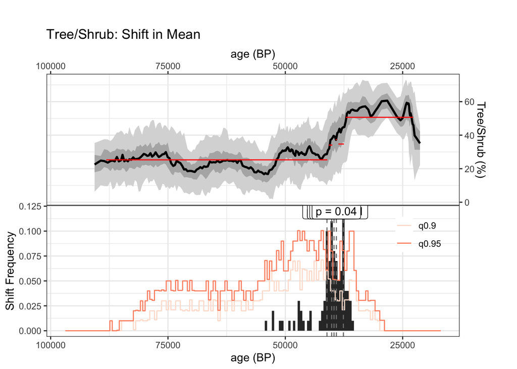

```r
treeShrubPlot <- plot(treeShrubMeanShift)
```

This figure visualizes many of the features of this analysis. First we see the identified intervals of abrupt change, as changes in the mean represented by the red line on the top panel, and as the black bars in the bottom panel, which show the proportion of ensemble members with detected abrupt changes during each 500-year window. Comparing this to the 95th percentile of changes found in the null model makes it clear that the shift that occurred about 39,000 years ago is a robust interval of abrupt change.

### 9.2.5 Links between climate and ecological change

Now that we’ve identified an interval of rapid change, let’s take a look at a nearby climate record, a sea surface temperature (SST) reconstruction from the Gulf of Guinea, to take a first look of whether the change in ecological communities might be driven by climate. Neotoma doesn’t host SST reconstuctions, so we’ll get these data from lipdverse.org a community repository of LiPD datasets.

```r
MD03_2707 <- readLipd("https://lipdverse.org/Temp12k/1_0_2/MD03_2707.Weldeab.2007.ensembles.lpd")
```

```
## [1] "reading: MD03_2707.Weldeab.2007.ensembles.lpd"
```

And as before, let’s take a look at the map.

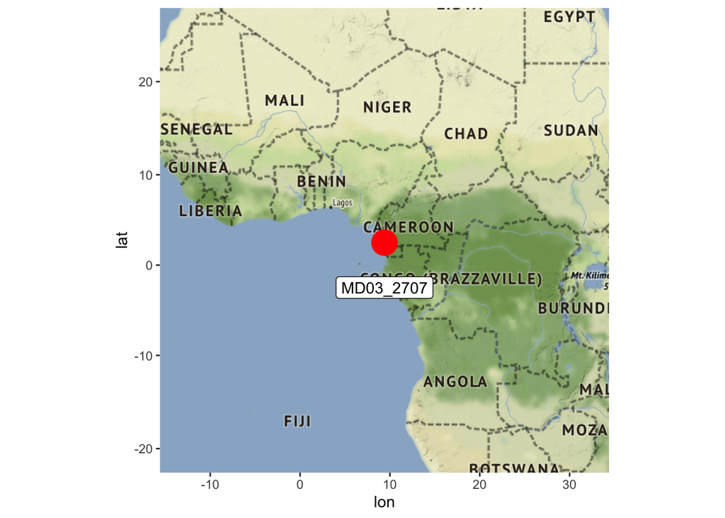

```r
mapLipd(MD03_2707,map.type = "stamen",extend.range = 5)
```

```r
MD03_2707_ts <- mapAgeEnsembleToPaleoData(MD03_2707) %>% as.lipdTsTibble()
```

```
## [1] "MD03_2707.Weldeab.2007"
## [1] "Looking for age ensemble...."
## [1] "Found it! Moving on..."
## [1] "Found it! Moving on..."
## [1] "getting depth from the paleodata table..."
## [1] "Found it! Moving on..."
```

As before, now we will use `actR` to detect shifts in the mean, while propagating uncertainties, and comparing the results to a robust null hypothesis. This time, since all the data are stored in the LiPD object, we can just pass in the lipd-ts-tibble object directly, and then tell it which dataset we’d like to analyze.

```r
MD03_2707_ms <-  actR::detectShift(MD03_2707_ts, #the lipd-ts-tibble that includes all the data
                   vals.variable.name = "SST_from_d18o_ruber_pink_ensemble", #the variable to analyze
                  summary.bin.step = 500, #same as before
                  time.range = c(20000,90000)) #same as before
```

```
## Selected SST_from_d18o_ruber_pink_ensemble
## timeUnits is at least partially absent in the input data
## Testing null hypothesis with 100 simulations, each with 100 ensemble members.
## This will probably take about 2 minutes
```

And as before, we can print out the summary

```r
MD03_2707_ms
```

```
## MD03_2707.Weldeab.2007 - SST_from_d18o_ruber_pink_ensemble: Shift in Mean results
## Searched for Shift in Mean with a minimum segment length of 1 years, summarizing the results over windows of 500 years.
##
## Overall result: Detected 11 Shift in Mean event(s) that were significant at the alpha < 0.05 level
## # A tibble: 11 × 3
##    time_start time_end empirical_pvalue
##         <dbl>    <dbl>            <dbl>
##  1      75700    76200           0
##  2      75200    75700           0
##  3      74700    75200           0
##  4      74200    74700           0
##  5      76200    76700           0
##  6      76700    77200           0
##  7      77200    77700           0
##  8      78200    78700           0
##  9      73200    73700           0
## 10      73700    74200           0
## 11      77700    78200           0.0100
## Time uncertainty considered? TRUE Time ensemble supplied (n = 100)
## Paleo uncertainty considered? TRUE Values ensemble supplied (n = 1000)
## Error propagation ensemble members = 100
## Null hypothesis testing ensemble members = 100
## Members simulated using isospectral method
##
## Parameter choices:
## cpt.fun = changepoint::cpt.mean
## minimum.segment.length = 1
## method = AMOC
## penalty = MBIC
## ncpts.max = 1
```

Once again, we find some intervals with significant changes in the mean. Let’s look at the plot to see how the timing of the abrupt shifts matches the ecological change.

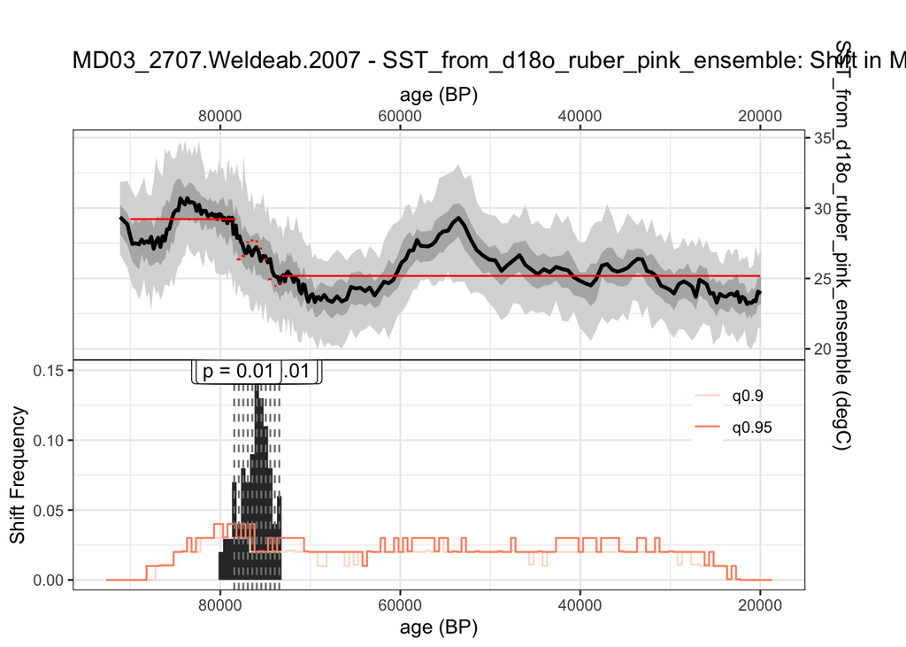

```r
MD03_plot <- plot(MD03_2707_ms)
```

`actR::detectShift()`, with the parameters used here, consistently identifies a change in mean between 80,000 and 70,000 years ago, and provides no evidence that the increase in trees and shrubs inferred from Lake Bambili pollen was associated with a change in SSTs in the nearby Gulf of Guinea.

Clearly, there is more work to be done here, this example simply highlights how these emerging R packages can be used to efficiently and reproducibly work with paleogeoscientific data from multiple repositories.

Blaauw, M., and J. A. Christen. 2011. “Flexible Paleoclimate Age-Depth Models Using an Autoregressive Gamma Process.” *Bayesian Analysis* 6 (3): 457–74.